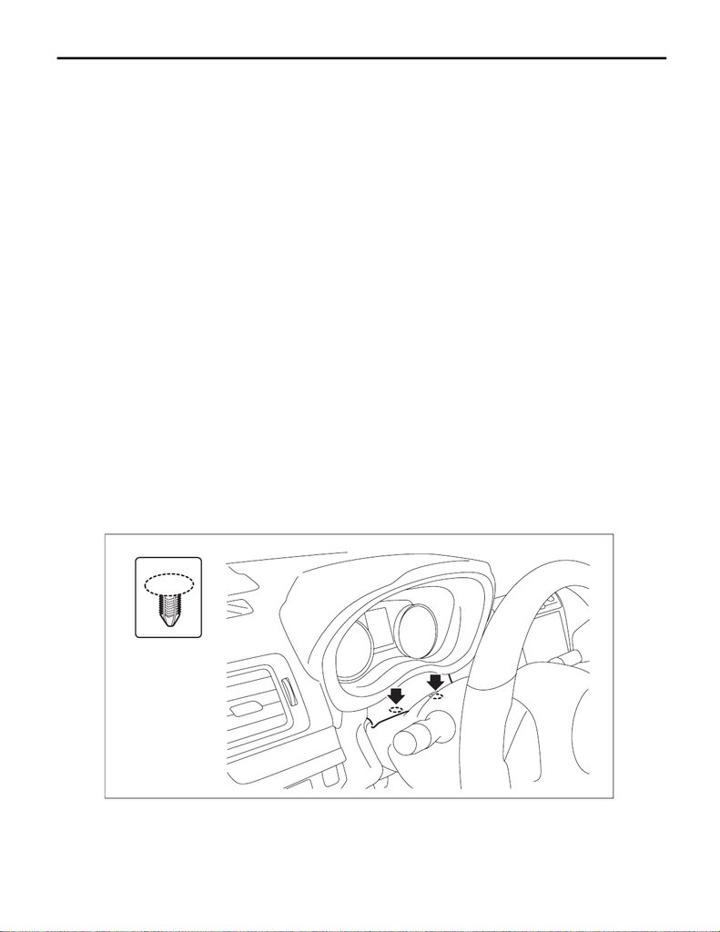

AB-65

Airbag Module Disposal (Deployment Processing on Vehicle)

AIRBAG SYSTEM

16.Airbag Module Disposal (Deployment Processing on Vehicle)

A: PROCEDURE

WARNING:

Make sure to follow the instructions below. Otherwise, personal injuries may occur.

• Do not touch the airbag module just after activation because it is very hot. Before handling it for

disposal, wait for 40 minutes.

CAUTION:

• Activating an airbag module causes a high explosive noise, be sure to warn people in the area, and

do not allow anyone within 5 m (16 ft) radius of the disposal site.

• Do not expose the activated airbag module to water.

• Wrap the activated airbag module in a sealed vinyl bag when discarding.

• If it is impossible to perform an airbag module operation process due to some situational reasons,

consult SUBARU dealership or one of the authorized workshops.

1. DRIVER’S AIRBAG MODULE

1) Turn the ignition switch to OFF.

2) Disconnect the ground cable from battery and wait for at least 60 seconds before starting work. <Ref. to

NT-5, BATTERY, NOTE, Note.>

NOTE:

For models other than STI model, disconnect the ground terminal from battery sensor.

3) Remove the cover assembly - column.

(1) Remove the clips, and remove the cover - column.

(2) Remove the screws.

(3) Remove the cap - key cylinder (a). (Model with keyless access)

PS-01710

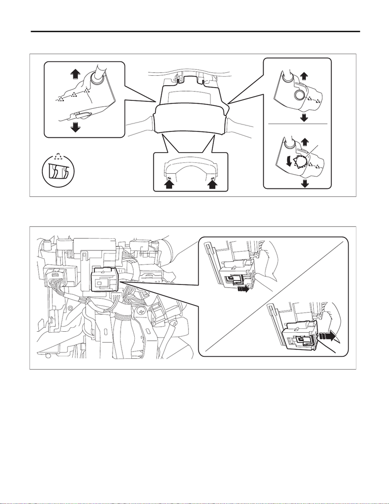

AB-66

Airbag Module Disposal (Deployment Processing on Vehicle)

AIRBAG SYSTEM

(4) Release the claw, and remove the cover assembly - column UPR and the cover assembly - column

LWR.

4) Disconnect the driver’s airbag module connector.

A Model without keyless access B Model with keyless access

PS-01384

A

B

(a)

AB-02396

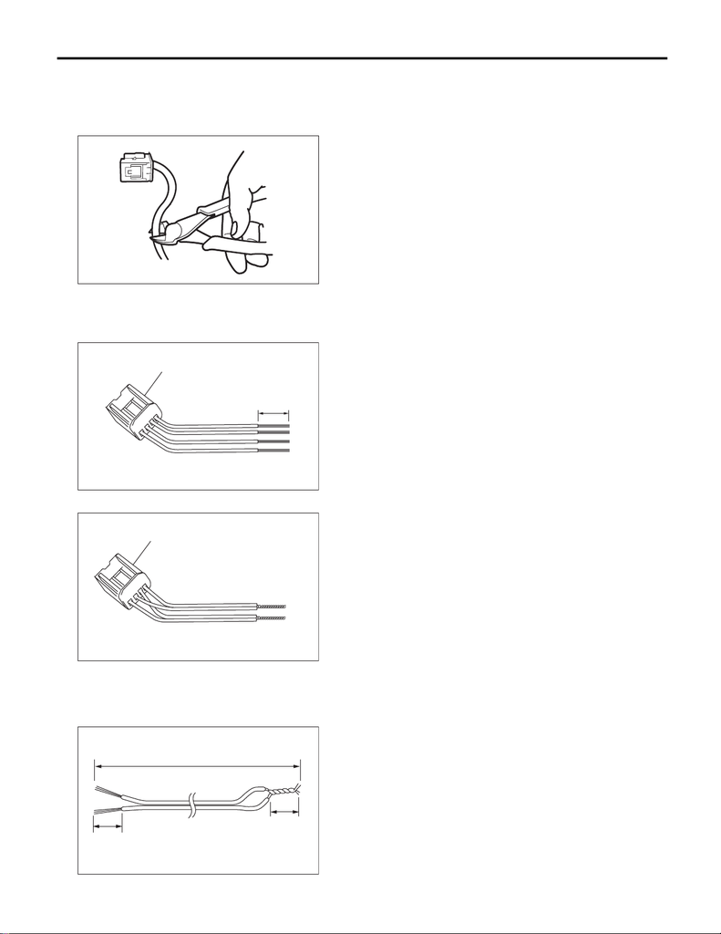

AB-67

Airbag Module Disposal (Deployment Processing on Vehicle)

AIRBAG SYSTEM

5) Cut off the harness on the body side of the removed connector approx. 70 mm (2.76 in) from the edge of

the connector.

Preparation tool:

Nippers

6) Peel off the shield approx. 20 mm (0.79 in) from the four harnesses of the removed body side connector.

Preparation tool:

Wire stripper

7) Twist the end of harness as shown in the figure.

8) Prepare two vinyl-shielded parallel wires of 6 m (19 ft) long. Peel off the shield of both ends approx. 20 mm

(0.79 in) and twist one end together into shorted condition.

AB-03581

AB-03579

Vehicle side connector

20 mm

(0.79 in)

AB-03580

Vehicle side connector

AB-03568

6m (19 ft)

20mm

(0.79 in)

20mm

(0.79 in)

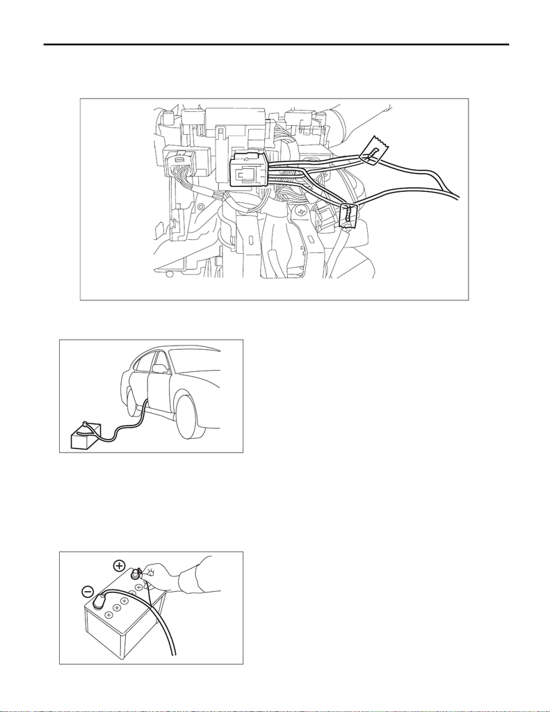

AB-68

Airbag Module Disposal (Deployment Processing on Vehicle)

AIRBAG SYSTEM

NOTE:

No concern about polarity.

10) After completing the connecting work, connect the body side connector to the connector of the airbag

connector lower side again.

11) Bring the vinyl wire for operation out of the vehicle and make sure there is no person in the vehicle.

13) Move the battery at least 5 m (16 ft) from the vehicle, and confirm safety in the area.

14) Connect the airbag deployment tool alligator clip to the battery negative (–) terminal.

CAUTION:

• After activation, the airbag module will be extremely hot. Let it cool down for at least 40 minutes in

an area with no one around.

• Do not expose the activated airbag module to water.

AB-03582

SB-00496

SB-00018

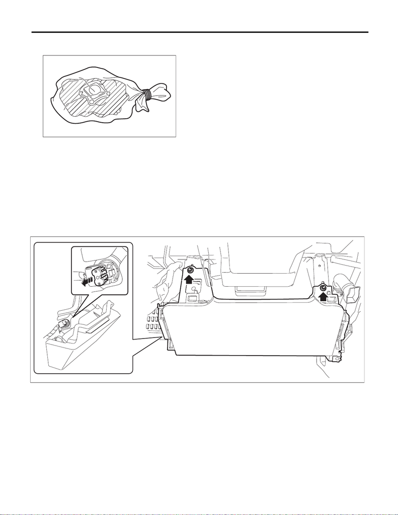

AB-69

Airbag Module Disposal (Deployment Processing on Vehicle)

AIRBAG SYSTEM

16) Remove the driver’s airbag module. <Ref. to AB-33, REMOVAL, Driver’s Airbag Module.>

17) Place the activated airbag module in a sealed vinyl bag, then discard.

2. KNEE AIRBAG MODULE

1) Turn the ignition switch to OFF.

2) Disconnect the ground cable from battery and wait for at least 60 seconds before starting work. <Ref. to

NT-5, BATTERY, NOTE, Note.>

NOTE:

For models other than STI model, disconnect the ground terminal from battery sensor.

3) Remove the cover assembly - instrument panel LWR driver. <Ref. to EI-61, REMOVAL, Instrument Panel

Lower Cover.>

5) Short the terminal to the alligator clip furnished as airbag deployment tool.

CAUTION:

Preparation tool:

ST: AIRBAG DEPLOYMENT TOOL (98299PA030)

AB-00591

AB-03557

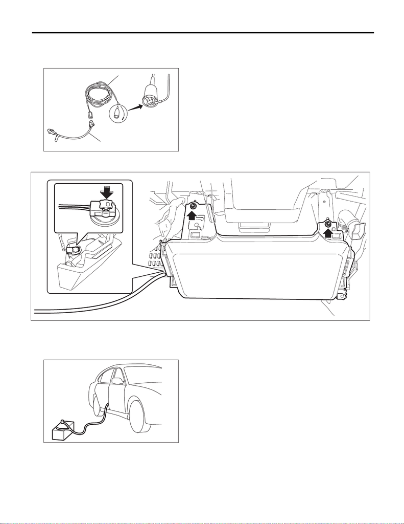

AB-70

Airbag Module Disposal (Deployment Processing on Vehicle)

AIRBAG SYSTEM

6) Connect the airbag deployment tool (A) and test harness adapter D (B).

Preparation tool:

ST: TEST HARNESS ADAPTER D (98299SA010)

7) Connect the test harness adapter D to the knee airbag module and install the knee airbag module to the

vehicle again.

Tightening torque:

7.5 N·m (0.8 kgf-m, 5.5 ft-lb)

8) Make sure there is no one inside the vehicle.

9) Extend the wiring of airbag deployment tool to the limit, and close all the windows and sunroof completely.

10) Move the battery at least 5 m (16 ft) from the vehicle, and confirm safety in the area.

11) Connect the airbag deployment tool alligator clip to the battery negative (–) terminal.

SB-00021

(A)

(B)

AB-03092

SB-00496

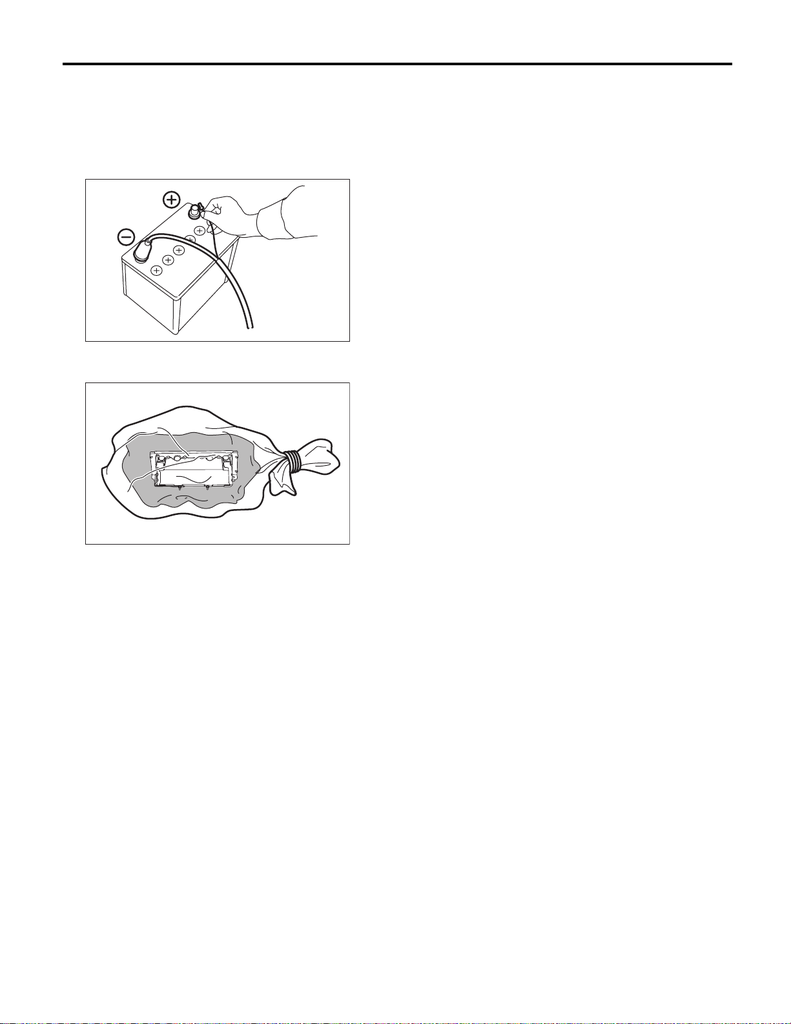

AB-71

Airbag Module Disposal (Deployment Processing on Vehicle)

AIRBAG SYSTEM

CAUTION:

• After activation, the airbag module will be extremely hot. Let it cool down for at least 40 minutes in

an area with no one around.

• Do not expose the activated airbag module to water.

13) Remove the bolts and remove knee airbag module.

14) Place the activated airbag module in a sealed vinyl bag, then discard.

NOTE:

When necessary, fold the fabric part of airbag into three or four sections, rope and seal in a vinyl bag.

SB-00018

AB-02502

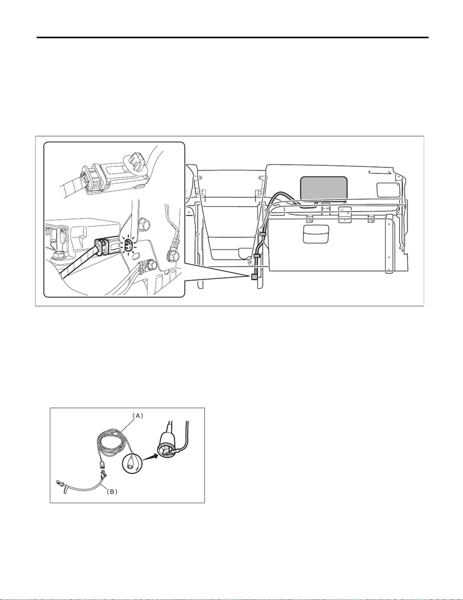

AB-72

Airbag Module Disposal (Deployment Processing on Vehicle)

AIRBAG SYSTEM

3. PASSENGER’S AIRBAG MODULE

1) Turn the ignition switch to OFF.

2) Disconnect the ground cable from battery and wait for at least 60 seconds before starting work. <Ref. to

NT-5, BATTERY, NOTE, Note.>

NOTE:

For models other than STI model, disconnect the ground terminal from battery sensor.

3) Remove the cover - shift lever, the panel center LWR RH, and the console box assembly. <Ref. to EI-67,

REMOVAL, Console Box.>

4) Disconnect the passenger’s airbag module connector.

5) Short the terminal to the alligator clip furnished as airbag deployment tool.

CAUTION:

Preparation tool:

ST: AIRBAG DEPLOYMENT TOOL (98299PA030)

6) Connect airbag deployment tool (A) and test harness adapter AM (B).

Preparation tool:

ST: TEST HARNESS ADAPTER AM (98299FJ000)

AB-02971

SB-00016

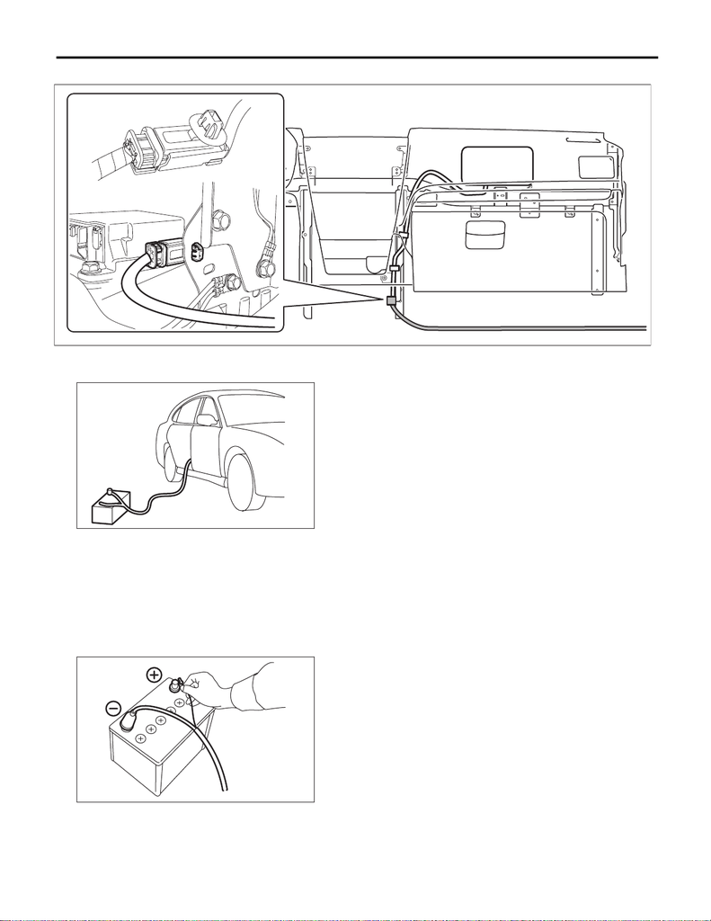

AB-73

Airbag Module Disposal (Deployment Processing on Vehicle)

AIRBAG SYSTEM

7) Connect test harness adapter AM to airbag connector.

8) Make sure there is no one inside the vehicle.

9) Extend the wiring of airbag deployment tool to the limit, and close all the windows and sunroof completely.

10) Move the battery at least 5 m (16 ft) from the vehicle, and confirm safety in the area.

11) Connect the airbag deployment tool alligator clip to the battery negative (–) terminal.

CAUTION:

• After activation, the airbag module will be extremely hot. Let it cool down for at least 40 minutes in

an area with no one around.

• Do not expose the activated airbag module to water.

13) Remove the passenger’s airbag module. <Ref. to AB-36, REMOVAL, Passenger’s Airbag Module.>

AB-02970

SB-00496

SB-00018

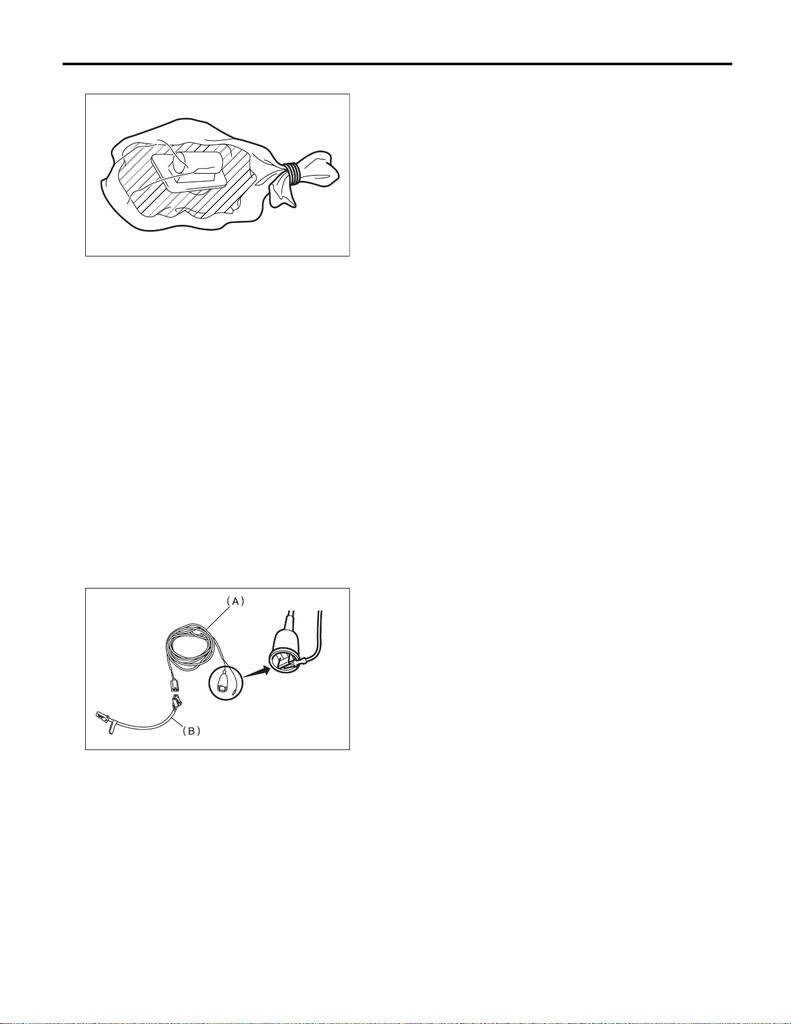

AB-74

Airbag Module Disposal (Deployment Processing on Vehicle)

AIRBAG SYSTEM

14) Place the activated airbag module in a sealed vinyl bag, then discard.

4. SIDE AIRBAG MODULE

1) Turn the ignition switch to OFF.

2) Disconnect the ground cable from battery and wait for at least 60 seconds before starting work. <Ref. to

NT-5, BATTERY, NOTE, Note.>

NOTE:

For models other than STI model, disconnect the ground terminal from battery sensor.

3) Disconnect the side airbag module connector under the front seat cushion. <Ref. to AB-23, SIDE AIRBAG

MODULE, PROCEDURE, Airbag Connector.>

4) Adjust both the front seat and front seat backrest to the center positions.

5) Short the terminal to the alligator clip furnished as airbag deployment tool.

CAUTION:

Preparation tool:

ST: AIRBAG DEPLOYMENT TOOL (98299PA030)

6) Connect the airbag deployment tool (A) and test harness adapter K (B).

Preparation tool:

ST: TEST HARNESS ADAPTER K (98299FG010)

7) Connect the test harness adapter K to side airbag module connector (yellow).

CAUTION:

Do not place any object on front seat.

8) Make sure there is no one inside the vehicle.

AB-00592

SB-00016

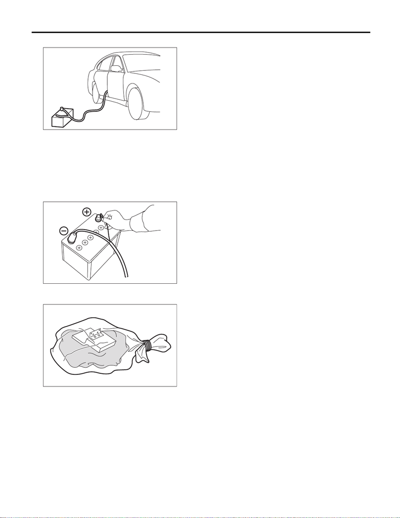

AB-75

Airbag Module Disposal (Deployment Processing on Vehicle)

AIRBAG SYSTEM

9) Extend the wiring of airbag deployment tool to the limit, and close all the windows and sunroof completely.

10) Move the battery at least 5 m (16 ft) from the vehicle, and confirm safety in the area.

11) Connect the airbag deployment tool alligator clip to the battery negative (–) terminal.

CAUTION:

• After activation, the airbag module will be extremely hot. Let it cool down for at least 40 minutes in

an area with no one around.

• Do not expose the activated airbag module to water.

13) Remove the side airbag module. <Ref. to AB-43, REMOVAL, Side Airbag Module.>

14) Place the activated airbag module in a sealed vinyl bag, then discard.

SB-00496

SB-00018

AB-00043

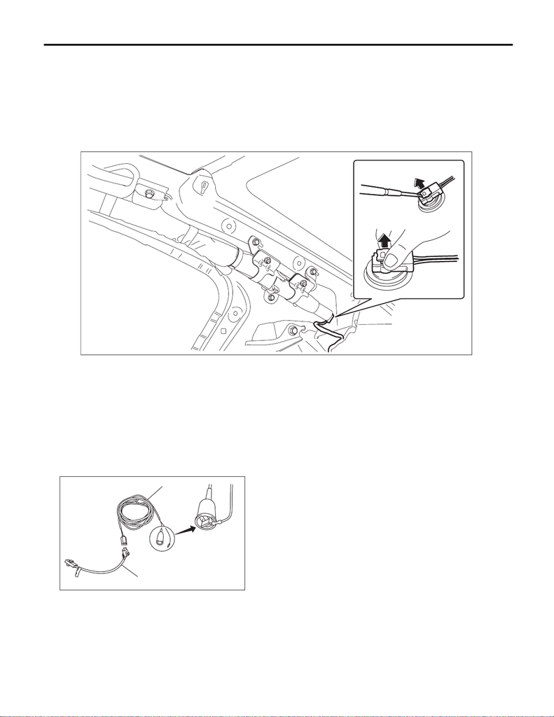

AB-76

Airbag Module Disposal (Deployment Processing on Vehicle)

AIRBAG SYSTEM

5. CURTAIN AIRBAG MODULE

1) Turn the ignition switch to OFF.

2) Disconnect the ground cable from battery and wait for at least 60 seconds before starting work. <Ref. to

NT-5, BATTERY, NOTE, Note.>

NOTE:

For models other than STI model, disconnect the ground terminal from battery sensor.

3) Remove the roof trim. <Ref. to EI-99, REMOVAL, Roof Trim.>

4) Disconnect the curtain airbag harness. <Ref. to AB-17, PROCEDURE, Airbag Connector.>

5) Short the terminal to the alligator clip furnished as airbag deployment tool.

CAUTION:

Preparation tool:

ST: AIRBAG DEPLOYMENT TOOL (98299PA030)

6) Connect the airbag deployment tool (A) and test harness adapter D (B).

Preparation tool:

ST: TEST HARNESS ADAPTER D (98299SA010)

AB-03556

(1)

(2)

SB-00021

(A)

(B)

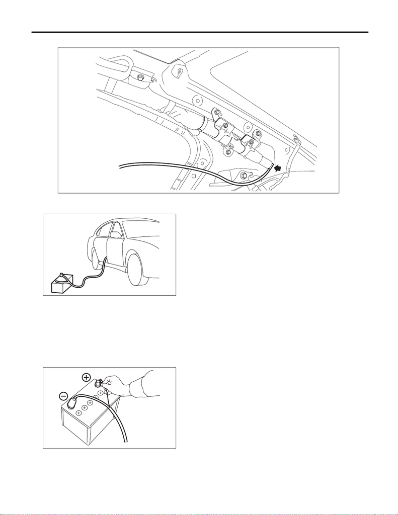

AB-77

Airbag Module Disposal (Deployment Processing on Vehicle)

AIRBAG SYSTEM

7) Connect the test harness adapter D to the curtain airbag module.

8) Make sure there is no one inside the vehicle.

9) Extend the wiring of airbag deployment tool to the limit, and close all the windows and sunroof completely.

10) Move the battery at least 5 m (16 ft) from the vehicle, and confirm safety in the area.

11) Connect the airbag deployment tool alligator clip to the battery negative (–) terminal.

CAUTION:

• After activation, the airbag module will be extremely hot. Let it cool down for at least 40 minutes in

an area with no one around.

• Do not expose the activated airbag module to water.

AB-03560

SB-00496

SB-00018

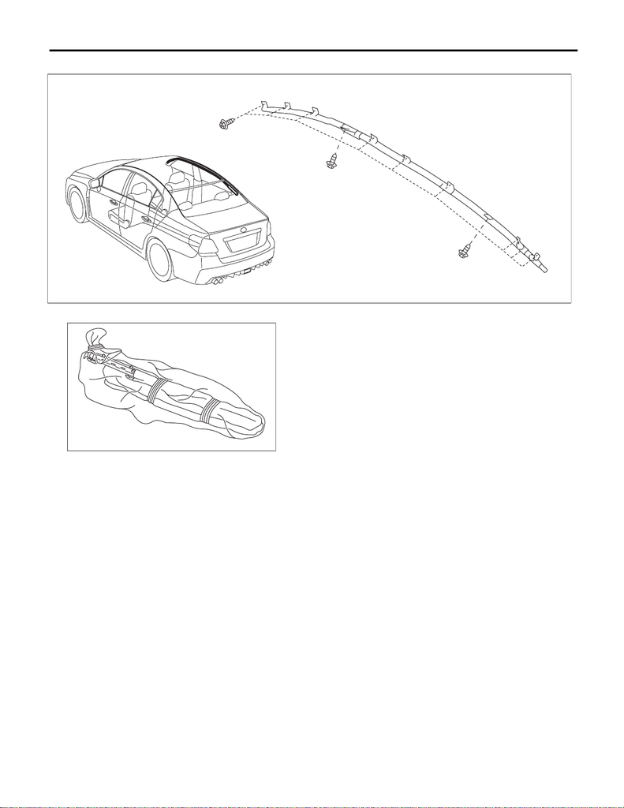

AB-78

Airbag Module Disposal (Deployment Processing on Vehicle)

AIRBAG SYSTEM

13) Remove the bolts and clips, and remove the curtain airbag module.

14) Place the activated airbag module in a sealed vinyl bag, then discard.

NOTE:

When necessary, fold the fabric part of airbag into three or four sections, rope and seal in a vinyl bag.

AB-03545

AB-00655

[figure not shown]

AIRBAG SYSTEM (DIAGNOSTICS)

AB(diag)

Page

1. Basic Diagnostic Procedure .......................................................................2

2. Check List for Interview ..............................................................................3

3. General Description ...................................................................................4

4. Electrical Component Location ................................................................17

5. Airbag Connector .....................................................................................19

6. Airbag Control Module I/O Signal .............................................................20

7. Subaru Select Monitor ..............................................................................22

8. Read Diagnostic Trouble Code (DTC) .....................................................25

9. Inspection Mode .......................................................................................26

10. Clear Memory Mode .................................................................................27

11. Read Current Data ...................................................................................28

12. Event Record Data ...................................................................................29

13. Batch save of Event record data ..............................................................30

14. Airbag Warning Light Illumination Pattern ................................................31

15. Airbag Warning Light Failure ....................................................................32

16. List of Diagnostic Trouble Code (DTC) ....................................................33

17. Diagnostic Chart with Trouble Code ........................................................42